# TRABAJO FINAL MÓDULO 7

Raquel Pacheco

2023-10-31

## **SECCION A**

Ve a la página del Banco Central de tu país y obtén cualquier variable de tu interés con frecuencia mensual o trimestral, mínimo 60 datos.

Realiza gráficos necesarios para comprender el comportamiento de la variable en estudio. Comenta en un par de párrafos lo que consideres.

Realiza los contrastes de raíz unitaria aprendidos. Reporta los resultados realiza los respectivos comentarios

VARIABLE UTILIZADA: CREDITO PANORAMA FINANCIERO

La variable “CREDITO PANORAMA FINANCIERO” es una métrica que se utiliza en el contexto financiero y económico para hacer un seguimiento de los créditos otorgados por el sector financiero de un país. Esta variable se relaciona con la cantidad de dinero prestado por instituciones financieras como bancos, cooperativas de crédito, y otras entidades financieras a individuos, empresas y otros prestatarios.

Cuando se trabaja con esta variable en el contexto de un análisis de series temporales, lo que se está haciendo es examinar cómo ha evolucionado el crédito otorgado a lo largo del tiempo. Esto implica recopilar datos históricos sobre el crédito concedido y observar cómo ha variado en diferentes períodos. Esta información es valiosa para comprender la dinámica económica de un país, ya que el crédito es un componente importante de la actividad económica y puede influir en variables como el consumo, la inversión y el crecimiento económico.

### Carga de las librerias

```r
library(foreign)
library(urca)
library(openxlsx)
library(highcharter)
library(forecast)
```

### Carga y manipulacion de la base de datos

```r
data<-read.xlsx("C:\\Users\\CompuStore\\Desktop\\CURSOS\\CIENCIA DE DATOS\\MODULO 7\\TRABAJO FINAL MODULO 7\\BASE TRABAJO FINAL.xlsx")
```

### Grafico de la variable

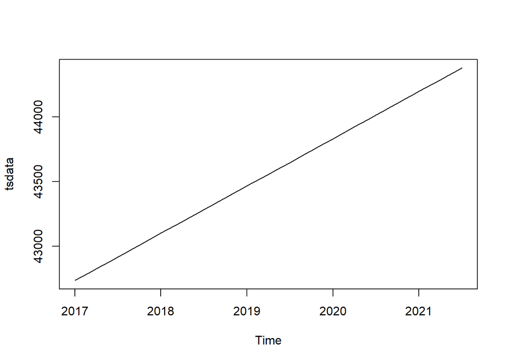

```r
tsdata <- ts(as.vector(as.matrix(data)),
             start=c(2017,1),
             end=c(2021,7),
             frequency = 12)
ts.plot(tsdata)
```

Al observar estos datos, es evidente que la serie de tiempo muestra una tendencia ascendente constante lo que significa que la variable (en este caso, el “Crédito Panorama Financiero”) está aumentando con el tiempo. Esto podría indicar un crecimiento constante o progresivo en la variable a lo largo del período analizado.

Tener una tendencia ascendente constante en una serie de tiempo puede ser una señal positiva desde el punto de vista financiero o económico, ya que sugiere un aumento en la métrica que se está observando. Sin embargo, es importante considerar otros factores y realizar un análisis más detallado para comprender completamente lo que implica este aumento. Por ejemplo, es importante evaluar si hay estacionalidad, ciclos u otros patrones que también puedan influir en los datos.

### Contrastes de raíz unitaria

```r
## Contraste Aumented Dickey Fuller

adftes<-ur.df(tsdata, type=c("trend"),
              selectlags=c("BIC"))
summary(adftes)
```

```
###############################################
# Augmented Dickey-Fuller Test Unit Root Test #
###############################################

Test regression trend


Call:
lm(formula = z.diff ~ z.lag.1 + 1 + tt + z.diff.lag)

Residuals:
     Min       1Q   Median       3Q      Max
-1.53617 -0.41901 -0.01998  0.35721  1.32251

Coefficients:
              Estimate Std. Error t value Pr(>|t|)
(Intercept) 28320.4316  6812.5873   4.157 0.000129 ***
z.lag.1        -0.6623     0.1596  -4.150 0.000132 ***
tt             20.1653     4.8577   4.151 0.000132 ***
z.diff.lag     -0.1632     0.1321  -1.235 0.222625
---
Signif. codes:  0 '***' 0.001 '**' 0.01 '*' 0.05 '.' 0.1 ' ' 1

Residual standard error: 0.6677 on 49 degrees of freedom
Multiple R-squared:  0.4353,    Adjusted R-squared:  0.4007
F-statistic: 12.59 on 3 and 49 DF,  p-value: 3.192e-06


Value of test-statistic is: -4.1505 69.5375 8.7732

Critical values for test statistics:
      1pct  5pct 10pct
tau3 -4.04 -3.45 -3.15
phi2  6.50  4.88  4.16
phi3  8.73  6.49  5.47
```

```r
## 4 ES > A 4, 3, 3? SI por lo tanto RH0

#REGLA

# si el valor calculado es > al valor critico RH0
# H0: Raiz unitaria
# Ha: Raiz no unitaria

# En este caso raiz unitaria= no estacionariedad
# Usted desea que no sea estacionaria es decir que no sea raiz unitaria

## Contraste Phillip y perron

pptes<- ur.pp(tsdata, type=c("Z-tau"),
              model=c("trend"),
              lags = c("short"))
summary(pptes)
```

```
##################################
# Phillips-Perron Unit Root Test #
##################################

Test regression with intercept and trend


Call:
lm(formula = y ~ y.l1 + trend)

Residuals:
     Min       1Q   Median       3Q      Max
-1.60320 -0.42040  0.03717  0.41596  1.39865

Coefficients:
             Estimate Std. Error t value Pr(>|t|)
(Intercept) 3.120e+04  5.742e+03   5.433 1.56e-06 ***
y.l1        2.839e-01  1.319e-01   2.153   0.0361 *
trend       2.180e+01  4.015e+00   5.428 1.59e-06 ***
---
Signif. codes:  0 '***' 0.001 '**' 0.01 '*' 0.05 '.' 0.1 ' ' 1

Residual standard error: 0.6964 on 51 degrees of freedom
Multiple R-squared:      1, Adjusted R-squared:      1
F-statistic: 1.253e+07 on 2 and 51 DF,  p-value: < 2.2e-16


Value of test-statistic, type: Z-tau  is: -5.4681

           aux. Z statistics
Z-tau-mu              5.1369
Z-tau-beta            5.9637

Critical values for Z statistics:
                     1pct      5pct     10pct
critical values -4.134754 -3.493511 -3.175277
```

```r
## 5 ES > A 4, 3, 3? SI por lo tanto se RH0

#REGLA

# si el valor calculado es > al valor critico RH0
# H0: Raiz unitaria
# Ha: Raiz no unitaria

# En este caso raiz unitaria= no estacionariedad

### Contraste KPSS

kpsstes<-ur.kpss(tsdata, type = c("tau"),
                 lag=c("short"))
summary(kpsstes)
```

```
#######################
# KPSS Unit Root Test #
#######################

Test is of type: tau with 3 lags.

Value of test-statistic is: 0.0849

Critical value for a significance level of:
                10pct  5pct 2.5pct  1pct
critical values 0.119 0.146  0.176 0.216
```

```r
## 0.0849 ES > A 0.119 no por lo tanto no RH0

#REGLA

# si el valor calculado es > al valor critico RH0
# H0: Estacionariedad
# Ha: No estacionariedad

## Contraste Elliot, Rothenberg & Stock Unit Root Test
## Contraste de alta potencia (menos sensible a valores atipicos)

erstest<-ur.ers(tsdata, type = c("DF-GLS"),
                model = c("trend"),
                lag.max = 4)
summary(erstest)
```

```
###############################################
# Elliot, Rothenberg and Stock Unit Root Test #
###############################################

Test of type DF-GLS
detrending of series with intercept and trend


Call:
lm(formula = dfgls.form, data = data.dfgls)

Residuals:
     Min       1Q   Median       3Q      Max
-1.81076 -0.28177 -0.03591  0.40243  1.32139

Coefficients:
             Estimate Std. Error t value Pr(>|t|)
yd.lag       -0.50204    0.18503  -2.713  0.00941 **
yd.diff.lag1 -0.21433    0.18601  -1.152  0.25530
yd.diff.lag2  0.08348    0.18093   0.461  0.64674
yd.diff.lag3  0.11537    0.16383   0.704  0.48494
yd.diff.lag4  0.01696    0.13584   0.125  0.90122
---
Signif. codes:  0 '***' 0.001 '**' 0.01 '*' 0.05 '.' 0.1 ' ' 1

Residual standard error: 0.674 on 45 degrees of freedom
Multiple R-squared:  0.3678,    Adjusted R-squared:  0.2976
F-statistic: 5.236 on 5 and 45 DF,  p-value: 0.0007145


Value of test-statistic is: -2.7134

Critical values of DF-GLS are:
                 1pct  5pct 10pct
critical values -3.58 -3.03 -2.74
```

```r
# -2.7134 es > a 3,3,2? no por lo tanto no RH0

# si el valor calculado es > al valor critico RH0
# H0: Raiz unitaria
# Ha: Raiz no unitaria

# En este caso raiz unitaria= no estacionariedad
```

## **SECCION B**

Realiza el análisis de la función de autocorrelación de la variable (original o transformada, según lo que indique las pruebas) y obtén el posible mejor modelo.

Considera analizar si la serie tiene algún comportamiento estacional para que sea considerado en este literal.

Siendo el mejor modelo (ARIMA o SARIMA según sea el caso), valida los resultados

Construye 4 pronósticos fuera de la muestra.

Con la misma variable, corre un auto.arima y realiza 4 pronósticos fuera de la muestra, con sus intervalos de confianza

En un gráfico de lineas, coloca la variable original, los valores ajustados del modelo final y los valores ajustados del modelo automático. Comenta los resultados.

### Complemento para ver de cuanto se necesita para convertir en estacionaria

```r
ndiffs(tsdata, test = c("kpss"))
```

```
[1] 1
```

```r
ndiffs(tsdata, test = c("adf"))
```

```
[1] 1
```

```r
ndiffs(tsdata, test = c("pp"))
```

```
[1] 1
```

## Primeras diferencias

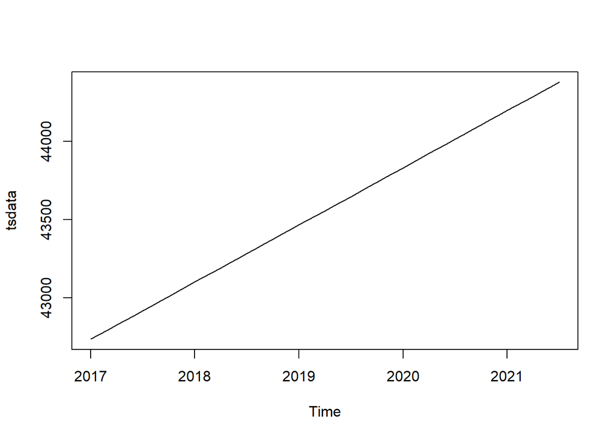

```r
plot(tsdata)
```

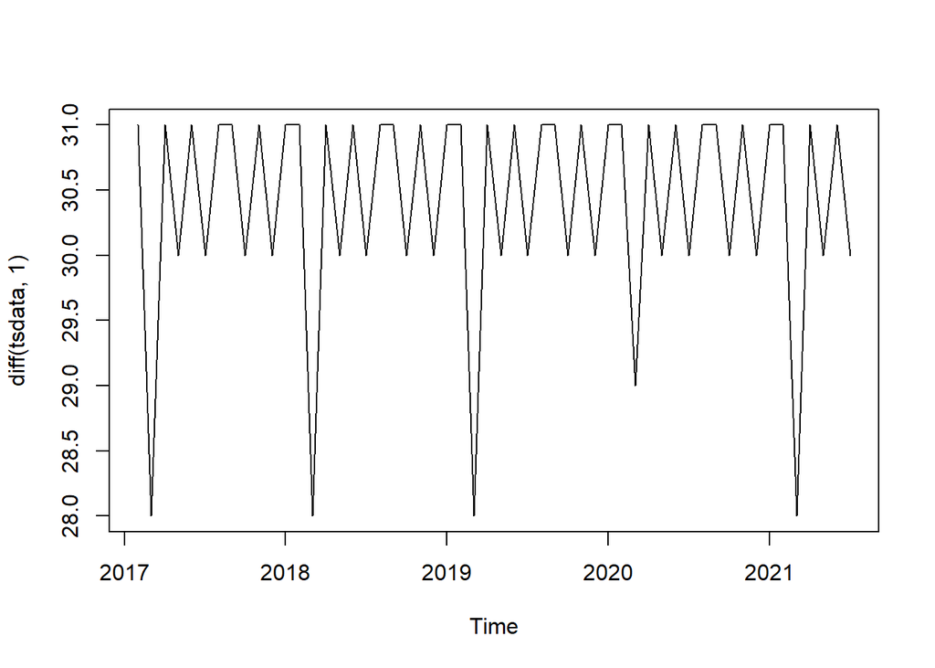

```r
plot(diff(tsdata,1))
```

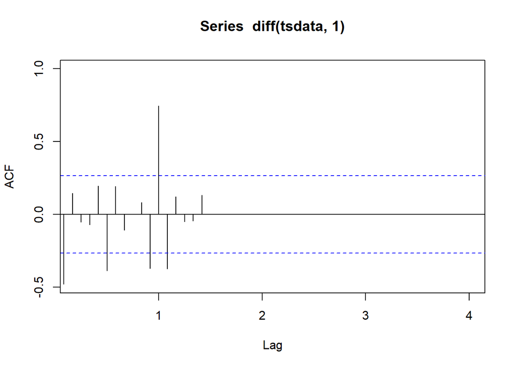

```r
## ¿que tipo de modelo arima es? Identificar

acf(diff(tsdata,1), xlim=c(0.2,4))
```

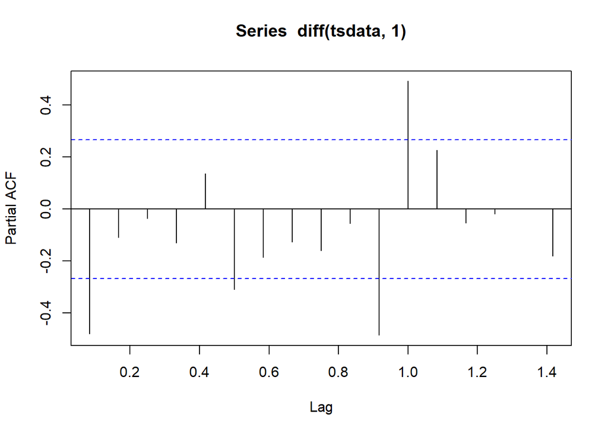

```r
pacf(diff(tsdata,1))
```

Aqui vemos que pondemos usar una media movil de orden 1, 6 y 11 y un autorregresivo de orden 1, 6 y 12. Sin embargo despues de hacer todas las combinaciones posibles, el mejor modelo para hacer es solo con una media movil de orden 1.